# GitHub Desktop: Power Hour

Research Data Management, Amsterdam UMC

Author

Sam Langton & Thomas Pronk

Published

December 2, 2024

## 1 Preamble

This material is a pilot workshop introducing [GitHub Desktop](https://github.com/apps/desktop) for researchers at [Amsterdam UMC](https://www.amsterdamumc.org/en/research.htm). It is partly based on material produced by [TIB Hannover](https://github.com/TIBHannover/git-desktop). The workshop is a compact, essentials-only session designed for students or researchers with zero familiarity with git/GitHub, but some familiarity with R. You can view the source material on the corresponding [repository](https://github.com/langtonhugh/github_desktop).

## 2 Version control

In this workshop you will be learning how to use **GitHub Desktop**. This is a point-and-click application that will allow you to use **version control**. Version control is a way of managing changes to code, in our case, R code. Once you’ve mastered the basics of version control using GitHub Desktop, you will be better able to track changes to your own code, revert to old versions of your scripts, collaborate with others, and avoid the worry of losing your work. At the very least, by the end of this session, you will never again have to use the classic (but deeply shameful) academic file naming system for your R scripts.

[figure not shown]

Rather than getting lost in a sea of nearly-identical files with different names (or even worse, only retaining the latest version) we can use version control. Version control tools start with a base version of a file – in this case, an R script – and then record any changes you make to the script as you go along. This could be deleting old code, editing existing code, or writing new code. At any point, you can revert to an old version or compare two different versions to assess what the differences are between these ‘snapshots’ of the same R script. In Git terminology, these snapshots are called **commits**.

[figure not shown]

[Image source](https://caltechlibrary.github.io/git-desktop/01-basics/)

Two (or more) collaborators can also independently make different changes to the same R script without worrying about overwriting what one another are doing. Along the way, each change to the script can be given a short description (e.g., “Recode age variable”) that helps you differentiate between different snapshots (i.e., **commits**)

[figure not shown]

[Image source](https://caltechlibrary.github.io/git-desktop/01-basics/)

And then later on, the two different versions can be **merged** into the same base R script.

[figure not shown]

[Image source](https://caltechlibrary.github.io/git-desktop/01-basics/)

Used properly, it is impossible to permanently lose work with version control. You will never have to frantically search through Outlook for an R script that you emailed to yourself, or frantically try and ‘restore previous version’ within Windows. Version control takes care of this for you!

**Self-questions**

- Imagine you have 5 co-authors on a paper. How would you manage the changes and comments they make to your paper? If you use Microsoft Word, what happens if you accept changes made using the Track Changes option? Do you have a history of those changes?
- Imagine you want to collaborate on an R script with a colleague. How would you go about this? Email the script back and forth with your changes? Share the script on a Cloud platform (e.g., One Drive, Google Drive)? If one of you made a mistake, deleting some important code, could you easily identify the change and remedy it?

## 3 Why GitHub Desktop?

So, we will be learning GitHub Desktop for version control. You might have heard various terms being thrown around with respect to version control, almost all of which will include the word ‘git’. Let’s clarify this. **Git** is the software doing the hard work: this is the thing that’s tracking changes to your R code. If you really want to, you can download [Git](https://git-scm.com/downloads), go away and use version control without any further tools.

Here, we recommend using Git via GitHub Desktop. There are two main reasons to this. First, using GitHub Desktop is one of the easiest and most lightweight ways to use Git for version control. It does not require any usage of the command line and it has a pretty good point-and-click user interface. Second, GitHub Desktop – as the name implies – works seamlessly with [github.com](https://github.com/), the largest online platform in the world for sharing and storing code. By using GitHub Desktop, you can not only put your code under version control with minimal effort, but you can also easily share your code with the world and remotely collaborate with your colleagues. Even if you work alone, and you do not want to share your code with anyone, [github.com](https://github.com/) can still be used to store your code privately, ensuring that all your versions are backed-up.

There are alternatives available, many of which also use Git under the hood, but GitHub has some advantages that means it will likely soon become the standard version control tool at Amsterdam UMC ([Pronk & Geertsma, 2024](https://zenodo.org/records/11065899)).

## 4 Solo exercise

### 4.1 Setup

The following steps are needed to follow along with the exercises:

1. If you haven’t already, [download R](https://cran.r-project.org/bin/windows/base/) and then [RStudio](https://posit.co/download/rstudio-desktop/).
2. [Sign-up](https://github.com/) to GitHub.
3. [Download](https://github.com/apps/desktop) GitHub Desktop.
4. Sign-in to your GitHub account within GitHub Desktop.
5. [Download the example R project](https://github.com/langtonhugh/github_desktop/raw/refs/heads/main/example_project.zip) that we will work with. Unzip it and place the folder somewhere on your local machine.

### 4.2 Adding a project to GitHub Desktop

In this exercise we assume that you have a small, pre-existing project for which you want to introduce version control. You can (and should) of course use version control from the very beginning of each project. For now, we use the example project above. Once saved and unzipped, it should look something like the screenshot below.

[figure not shown]

Currently, nothing we are doing is under version control. No changes are being tracked. If we delete some R code, it’s probably gone forever, and we cannot easily compare or restore to a previous version. To begin tracking the project using Git, we can add it to GitHub Desktop using `File / New repository`. A repository is the term for the digital storage space on GitHub that includes your code and code-related documentation. So, typically the repository consists of the folder on your computer containing all your code-related research materials. It’s the folder that we want to put under version control.

[figure not shown]

You will then be prompted to complete some information about the repository. Because we already have a pre-existing folder, the name of the repository is the name of the folder i.e., `example_project`. This must match your folder name exactly! You can add a short description if you’d like. The `Local path` points GitHub Desktop towards the location of `example_project` (in our case, within the `training` folder). As you select this, check that the summary at the bottom of the window (where is says `The repository will be created at...`) is accurate! We tick the box for a README, which is where we write the code-related documentation for the project, and then select `R` for the Git ignore. We will cover these two things later! In the example below, we do not select a licence, but by all means select one if you’d like.

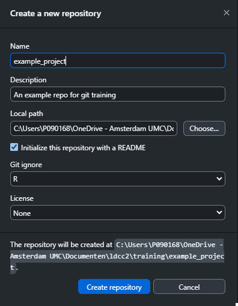

Then click `Create repository`. You will then get something like the screenshot below. Your project is now under version control and has been added to GitHub Desktop!

[figure not shown]

### 4.3 Editing a script

How can we tell that we are now using Git for version control? One easy way to check is just to make an edit to your R script. Open up the R project `example_project.RProj`. This is the file highlighted in the screenshot of our folder above. If you’re not sure what an R project file is you can [read more here](https://support.posit.co/hc/en-us/articles/200526207-Using-RStudio-Projects). Opening the R project file will launch RStudio. Then open the `my_analysis.R` script in the RStudio session. If needed, install the packages required to run the script. You don’t actually have to understand or even run the script to follow the exercise, but it will allow you to test things out more if you can get it running.

Now, make an edit to the R script. This could be a meaningful edit to the code or something trivial like a comment saying “Hello”. In my example, I just add some code to change the palette used in the ggplot. What happens in GitHub Desktop? You will see some red/green annotation of your change on the right, and a summary of the files changed (in this case, just `my_analysis.R`) on the left.

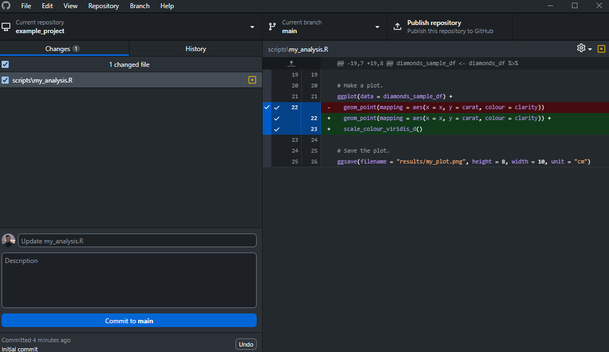

### 4.4 Making a commit

While we can see that Git is tracking these changes, we have not yet taken a ‘snapshot’ of what we’ve done. To do that, we need to make a **commit**. You will notice that once a change is made, the option for making a commit appears in the bottom left, including a pre-filled description of our change (“Update my_analysis.R”). You can write your own description. Next, click `commit to main`.

[figure not shown]

Once you’ve done that, nothing really appears to happen. But, when you click on `History` in the top left, you can see your commit history. You will notice that by default, we made an `Initial commit` when creating the repository. Click on it and look at what we added. Then try making some new changes, making a commit after each one, and then look at the `History` tab. You can edit the code, save a new plot and/or save new data. An example of my commit history is below.

[figure not shown]

You can go away and use GitHub Desktop on your own just like this. After each major change to your script, you can make a commit and keep working in the same script safe in the knowledge that you can go back and retrieve old code whenever you want. You do not even need access to the internet to do this. But, one major advantage of GitHub Desktop comes from **pushing** stuff to GitHub.

### 4.5 Pushing your changes

Back on the `Changes` tab, you will notice a prompt about publishing your repository. As the message says, your repository and all its commits only exist on your local machine. To make it available on [github.com](https://github.com/) we need to publish it. Click on `Publish repository`. You will notice that now we have the option to make the code private. Untick this box (so it’s public) and then click `Publish repository` again.

[figure not shown]

In Git terminology, you are now **pushing** your (local) commits to the **remote** repository (i.e, the repository on [github.com](https://github.com/)). This push is unique because it’s our first one, so the push is combined with publishing the repository online (it did not exist online before). If you click `View on GitHub` (in the right panel) you will be taken to this remote repository. It now exists online!

You will notice that the remote repository contains everything you’ve done, including the commit history. All your previous snapshots have been stored, backed-up online, and are now available to others.

[figure not shown]

Note that now, your remote repository (i.e., the one on github.com) mimics our local repository (i.e., the one on your laptop). That’s because we commit + pushed all our changes to the remote. But what happens if we or someone else changes something on the remote repository? How can we update our local repository with those changes? We will practice playing with that now by using the README file.

### 4.6 Pulling changes to the README

You might remember that when we created the repository, we created a README file. This is a very important file: it can be used to document your repository, both for your (future) self and for others that might want to use your code. The file is called `README.md` in your repository. The contents of that file is rendered and displayed on the main landing page of your remote repository on [github.com](https://github.com/). If you want, you can edit this file within something like notepad, commit the change, and push your changes to the remote repository, and in doing so the description on the public repository online will change.

Here, we want to practice a **pull**. This is the opposite of a **push**. Instead of **pushing** changes from our local machine to the remote repository on [github.com](https://github.com/) we can **pull** changes that exist on the remote but not on our local machine. To practice this, we are going to edit our README on the remote repository, and then **pull** those changes so that we have them on our local machine. Click the edit button of the README on the remote repository web page.

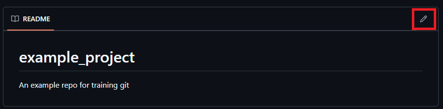

Make some changes to the file. Note that it uses [markdown](https://www.markdownguide.org/basic-syntax/) syntax (with some special [GitHub flavoring](https://docs.github.com/en/get-started/writing-on-github/getting-started-with-writing-and-formatting-on-github/quickstart-for-writing-on-github)), although you don’t need to know markdown to make an edit. Add some details to your README and then click `Commit changes` (in green). When you make changes directly to the remote repository on [github.com](https://github.com/), you don’t need to **push** anything. The commit on its own is enough to change the contents of the remote repository.

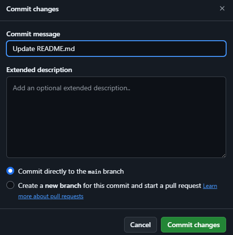

Now, how can we update our local repository with these changes? We can check for changes on the remote by clicking `Fetch origin` within GitHub Desktop.

[figure not shown]

We will then be notified that there’s been a change on the remote (i.e., our edit to the README) and receive a prompt to **pull** from the remote. Click this now!

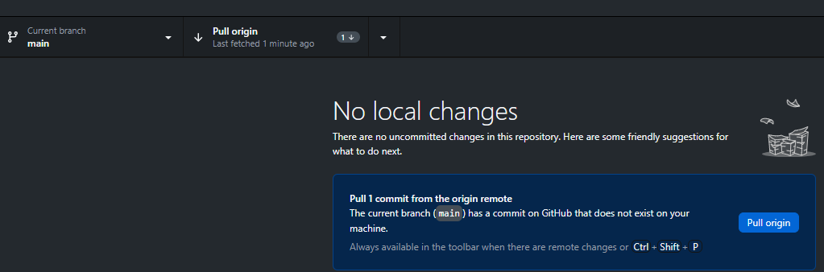

If you now check your `README.md` on your local repository, you should now see any changes that were made on the remote repository. You will also notice that your `History` tab has been updated with the commit we made directly to the remote.

In practice, most things that we **pull** from the remote repository are changes that someone else has made to the remote via a commit and push on their own machine, such as adding some new code to our script. If Person A pushes some new code to the remote repository, then Person B can then pull their changes to their local machine, for further edits or testing. We cover this during an exercise later.

**Self-study**

Now you’ve successfully pulled changes to the README from the remote, have a go at doing it the other way around. Open up `README.md` in a text editor (e.g., notepad), make some changes, and then **commit** and **push** those changes to the remote.

### 4.7 Note on data

You will have noticed that our data file `diamonds_data.csv` in the `data` folder is also under version control and is being hosted on the remote GitHub repository. It’s worth adding that normally, especially with (potentially sensitive) medical data, the data itself will **not** be a GitHub. This is partly because GitHub repositories have limited storage space, but also because of data privacy. Your data will likely have to be stored on a secure network drive, or if the data is open, on a more data-specific online repository (e.g., [OSF](https://osf.io/)).

## 5 Collaboration exercise

Now that you’ve practiced some stuff on your own, we can extend the exercise to simulate a collaboration with a research colleague. To do this, you will need a colleague! If you can’t find a friendly colleague to practice this exercise with, and you’re a member of Amsterdam UMC, then we could help you out. Make a request to [RDM Research Software Management via ServiceNow](https://amsterdamumc.service-now.com/esc?id=sc_cat_item&sys_id=6edc44311bea4110f2ae6313604bcbc4), and we will schedule an appointment to help you.

Let’s say you have a colleague that’s really good at making fancy looking ggplots. You want them to contribute to the script in your repository. A straightforward way of doing this is to add them as a collaborator. On the repository webpage at [github.com](https://github.com/), click on `Settings` and then `Collaborators`. After going through the two-factor check, click `Add people` and then search for your colleague’s GitHub username. Here, I choose my esteemed colleague [Thomas Pronk](https://github.com/tpronk) and click `Add tpronk to this repository`. Obviously, please choose your colleague’s username!

[figure not shown]

Your colleague will now get an invite to be a collaborator, which we hope they will enthusiastically accept. But even then, they do not have any of your data and code. No, don’t email it to them… Instead, your colleague can **clone** your remote repository onto their local machine. Before proceeding, make sure you’ve pushed all your local changes to the remote, so that your colleague is getting the latest version of your project.

Your colleague can make a clone by navigating to your remote repository on [github.com](https://github.com/), clicking on the green `Code` button, and then clicking `Open with GitHub Desktop`.

[figure not shown]

Within GitHub Desktop, your colleague will now have a pre-filled window with the URL of the remote repository, and the location where the repository will be cloned to. Remember that in the screenshot below the URL should be **your** repository (i.e., not langtonhugh!). Your colleague can change the location under `Local path` as they’d like and then click `Clone`.

[figure not shown]

If all has gone to plan, each of you should now have a version of the research materials (i.e., the `example_project` folder) on your machines. To practice a collaboration, have one of you make some changes to the R script – edit something, add something or delete something. **Commit** and **push** those changes to the remote. The other person can then **fetch** and **pull** those changes from the remote. Continue doing this for a couple of iterations in order to practice the process.

So far, you have been taking turns editing the same code chunk. In reality, you might not know when your colleague is working on the R script. What happens if you edit the same chunk of code and attempt to push those changes to the remote repository? You might get a warning message about a **conflict**. These conflicts need to be resolved before pushing. We don’t cover conflicts in detail during this workshop but I would recommend [this video](https://www.youtube.com/watch?v=MIVW0sijSjY) for a concise summary. Note that the example does not use R, but the principle is the same! In practice, there are a couple of ways you can avoid conflicts:

- Commit and push your changes frequently. Do **not** make a big changes, sit on them for weeks, and then decide to push.
- Fetch and pull frequently. This ensures that you will always have the most recent changes to the remote on your local machine.
- Communicate with your colleague(s). The chances are that it’s not that productive for multiple people to be working on the same lines of code at the same time. You probably wouldn’t edit the same paragraph in a paper collectively either!

## 6 Git ignore

When we created our repository, we selected a Git ignore option for `R`. You might have noticed that this created a file in your repository called `.gitignore`. You can open this file up in a text editor like notepad. The git ignore file states everything that you do **not** want to track with version control. Typically, the git ignore will list things that you do not want pushed to a public repository on [github.com](https://github.com/), such as data files or personal notes. When we created our repository with GitHub Desktop, we chose a pre-completed git ignore file specifically designed for the R programming language. You do not have to do this, but it does contain some sensible decisions, such as ignoring session data files (`.RData`). For your own projects, you can create your own or edit the template file for R.

To test things out, create a text file within your `scripts` folder. You should see this appear on GitHub Desktop as a change. Now add this text file to your git ignore, and save it. Note that you will have to specify that it lives within the `scripts` folder (i.e., `scripts/my_text_file.txt`). What happens? It should disappear from your changes in GitHub Desktop. Git is no longer tracking it!

Now, what happens if you add a previously-pushed file, like your `my_analysis.R` script, to the git ignore? Or even the `diamonds_data.csv` file? If you then make a commit and push your changes to the remote, does anything change on the remote repository?

Version control is almost always a blessing, but it can also be a curse. If you push something to your remote repository, and then subsequently decide that you want Git to ignore that file, the file will still be retrievable in the remote commit history! So, think carefully about what **do** and **do not** want to be tracked and available on your public repository. If you’re not sure about this, please get in contact with the Research Data Management team, and we can schedule a consultation appointment.

## 7 Git within RStudio

We’ve focused on GitHub Desktop, which means you will be able to use version control with any programming language in exactly the same way as we’ve covered here. If you are likely to stick with R, you can make use of the built-in Git functionality of RStudio. Assuming you are on a reasonably recent version of RStudio, you will notice this tab in the top right.

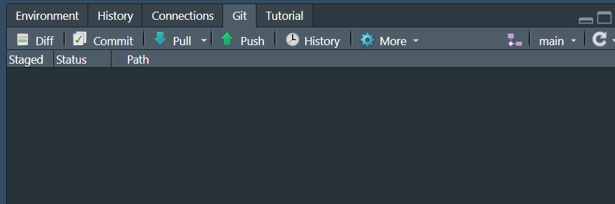

Many of these options will be familiar to you (e.g., **commit**, **pull**, **push**). The principles of Git are exactly the same as we covered within GitHub Desktop, but this tab means you don’t have to leave RStudio to use version control.